# Enhancing Data Integrity: Exploring Imputation Methods for Missing Values in the Titanic Dataset

Boning Liu

02-19-2025

# 1 Introduction: Understanding Missing Values and Imputation Methods

## 1.1 Dataset Overview

The Titanic dataset records information about passengers aboard the RMS Titanic’s ill-fated voyage. It includes demographic details, ticket class, fare price, and survival status. This dataset is widely used for machine learning due to its mix of numerical and categorical variables, as well as its incomplete data, making it an ideal case study for handling missing values.

Among the **891** records in this dataset, certain features contain missing values:

- **Age**: Missing for **177** passengers (~20% of the data).
- **Cabin**: Missing for **687** passengers (~77% of the data).
- **Embarked**: Missing for **2** passengers.

Since missing values can distort analytical conclusions and reduce the predictive power of models, we explore multiple imputation strategies in this assignment.

## 1.2 Nature of Missing Values

Missing data can occur due to various reasons, such as incomplete record-keeping, human error, or non-responses in surveys. In the Titanic dataset:

- **Cabin data is largely missing**, possibly because only certain passengers had assigned cabins.
- **Age is missing for some passengers**, potentially due to inconsistent documentation.
- **Embarked has minor missing values**, which could be a result of recording errors.

If left unaddressed, missing values can bias results, decrease statistical power, and lead to ineffective machine learning models.

## 1.3 Methods of Imputation

To handle missing data, we will explore the following techniques:

1. **Replacement Imputation**
- **Mode Imputation**: Fills missing categorical values with the most frequently occurring category.
- **K-Nearest Neighbors (KNN) Imputation**: Estimates missing values based on similar data points in the dataset.
2. **Regression-Based Imputation**
- Uses a **predictive model** to estimate missing values for numerical features based on relationships with other variables.
3. **Multiple Imputation (MICE)**
- Generates multiple plausible values for missing data, allowing for uncertainty in imputations.

## 1.4 Importance of Imputation in Machine Learning

Properly addressing missing data ensures that models do not suffer from **data leakage, bias, or loss of valuable information**. Choosing the right imputation technique improves dataset completeness and enhances the reliability of machine learning models. This assignment examines different imputation methods to determine their impact on data quality and downstream predictions.

```r
# Import Titanic dataset from GitHub
url <- "https://raw.githubusercontent.com/BrianL0201/BrianL0201.github.io/refs/heads/main/STA552%20Machine%20Learning/train.csv"
titanic_data <- read.csv(url, stringsAsFactors = TRUE)  # Convert categorical variables to factors automatically

# Convert empty strings to NA across all columns
titanic_data[titanic_data == ""] <- NA

# Check missing values
colSums(is.na(titanic_data))
```

```
PassengerId    Survived      Pclass        Name         Sex         Age
          0           0           0           0           0         177
      SibSp       Parch      Ticket        Fare       Cabin    Embarked
          0           0           0           0         687           2
```

# 2 Replacement Imputation for Categorical Features

Categorical features with missing values can cause inconsistencies in data analysis and modeling. In this section, we **applied replacement imputation techniques** to handle missing values in the **Embarked** and **Cabin** variables. Two methods were used: **Mode Imputation** for **Embarked** and **K-Nearest Neighbors (KNN) Imputation** for **Cabin**.

## 2.1 Step 1: Mode Imputation for Embarked

Since **Embarked** has only 2 missing values, we will replace them with the most frequently occurring value.

**Expected Outcome**:

- The missing values in Embarked will be replaced with “**S**” (**Southampton**), the most common value.
- Running **sum(is.na(titanic_data$Embarked))** should return **0**.

```r
# Identify the most common embarkation port
mode_embarked <- names(sort(table(titanic_data$Embarked), decreasing = TRUE))[1]

# Replace missing values with the mode
titanic_data$Embarked[is.na(titanic_data$Embarked)] <- mode_embarked

# Verify missing values in Embarked
sum(is.na(titanic_data$Embarked))
```

```
[1] 0
```

**Result**: The missing values in **Embarked** were successfully filled, and its distribution remained largely unchanged.

## 2.2 Step 2: KNN Imputation for Cabin

Since **Cabin** has **687** missing values, we will use **K-Nearest Neighbors (KNN) Imputation** to estimate missing values based on similar passengers.

**Expected Outcome**:

- Missing values in **Cabin** will be imputed based on 5 nearest neighbors.
- Running **sum(is.na(titanic_data$Cabin))** should return 0.

```r
# Convert Cabin to a factor
titanic_data$Cabin <- as.factor(titanic_data$Cabin)

# Apply KNN Imputation (k=5)
titanic_data <- knnImputation(titanic_data, k = 5)

# Verify missing values in Cabin
sum(is.na(titanic_data$Cabin))
```

```
[1] 0
```

**Result**: The missing values in **Cabin** were replaced using the patterns from neighboring data points, reducing the impact of being missing while preserving meaningful relationships.

## 2.3 Conclusion

The applied imputation methods ensured that categorical missing values were handled effectively. Mode imputation worked well for **Embarked** due to its minimal missing values, while KNN imputation provided a more sophisticated approach for **Cabin**, which had significant amount of missing values. These imputations help maintain dataset completeness and improve the quality of subsequent machine learning models.

# 3 Regression-Based Imputation for Age

### 3.0.1 Introduction

Missing values in numerical features can affect predictive modeling, requiring appropriate imputation methods. In this section, we used **regression-based imputation** to estimate missing values in the **Age** variable. By leveraging relationships between **Age** and other passenger attributes, we filled missing values while preserving statistical patterns.

## 3.1 Step 1: Prepare Data for Regression

We first check for missing values and select relevant predictor variables:

**Expected Outcome**:

- Confirms that Age has **177** missing values.
- Ensures categorical variables are correctly formatted for regression.

```r
# Reset Age missing values
titanic_data$Age <- read.csv(url, stringsAsFactors = TRUE)$Age  # Reload Age column from original dataset

# Check missing values in Age
sum(is.na(titanic_data$Age))
```

```
[1] 177
```

```r
# Select predictor variables
predictors <- c("Pclass", "Fare", "SibSp", "Parch", "Sex")

# Convert categorical variables to factors if not already done
titanic_data$Pclass <- as.factor(titanic_data$Pclass)
titanic_data$Sex <- as.factor(titanic_data$Sex)
```

## 3.2 Step 2: Train the Regression Model

We use **complete cases** (rows where **Age** is not missing) to train a linear regression model.

**Expected Outcome**:

- Displays **which variables significantly predict Age**.
- Shows **model coefficients**, indicating relationships between features.

```r
# Train a linear regression model using only complete cases
age_model <- lm(Age ~ Pclass + Fare + SibSp + Parch + Sex, data = titanic_data, na.action = na.omit)

# Summary of the model
summary(age_model)
```

```
Call:
lm(formula = Age ~ Pclass + Fare + SibSp + Parch + Sex, data = titanic_data,
    na.action = na.omit)

Residuals:
    Min      1Q  Median      3Q     Max
-36.389  -8.301  -0.714   7.126  45.285

Coefficients:
             Estimate Std. Error t value Pr(>|t|)
(Intercept)  40.85656    1.52796  26.739  < 2e-16 ***
Pclass2     -10.26017    1.55152  -6.613 7.43e-11 ***
Pclass3     -15.00139    1.46231 -10.259  < 2e-16 ***
Fare         -0.02589    0.01179  -2.195  0.02848 *
SibSp        -3.80970    0.55921  -6.813 2.05e-11 ***
Parch        -0.70529    0.63139  -1.117  0.26436
Sexmale       3.06157    1.03726   2.952  0.00327 **
---
Signif. codes:  0 '***' 0.001 '**' 0.01 '*' 0.05 '.' 0.1 ' ' 1

Residual standard error: 12.7 on 707 degrees of freedom
  (177 observations deleted due to missingness)
Multiple R-squared:  0.2427,    Adjusted R-squared:  0.2362
F-statistic: 37.75 on 6 and 707 DF,  p-value: < 2.2e-16
```

## 3.3 Step 3: Predict Missing Age Values

We predict missing **Age** values using the trained model and add some **random noise** to maintain natural variability.

**Expected Outcome**:

- All missing **Age** values are now filled.
- Introduces slight variation in predicted values to prevent **overfitting**.

```r
# Identify rows with missing Age
missing_age_rows <- which(is.na(titanic_data$Age))

# Predict Age for missing values
predicted_age <- predict(age_model, newdata = titanic_data[missing_age_rows, ])

# Add random noise based on model residual standard error
random_error <- rnorm(length(predicted_age), mean = 0, sd = summary(age_model)$sigma)
titanic_data$Age[missing_age_rows] <- predicted_age + random_error

# Verify missing values in Age after imputation
sum(is.na(titanic_data$Age))
```

```
[1] 0
```

## 3.4 Analysis of Regression-Based Imputation for Age

### 3.4.2 Successful Age Imputation

- The second output confirms **all missing Age values have been filled (sum(is.na(titanic_data$Age)) = 0)**.
- **Random noise was added** to prevent overfitting, making the imputations more natural.

### 3.4.3 Conclusion

Regression-based imputation provided a structured approach to filling in missing **Age** values based on meaningful relationships in the dataset. This method preserves statistical integrity while reducing bias, making it a reliable option for handling missing numerical data.

# 4 Multiple Imputation Using MICE

## 4.1 Introduction

Missing values in datasets can lead to biased analyses and reduced predictive power in machine learning models. While previous methods such as **mode imputation** and **regression-based imputation** provide effective solutions, they do not account for uncertainty in missing values. **Multiple Imputation by Chained Equations (MICE)** offers a more robust alternative by generating multiple plausible imputations for missing values.

In this section, we apply **MICE imputation** to estimate missing values in the **Age** variable using information from other features in the dataset. Unlike single imputation methods, **MICE generates multiple imputed datasets** to capture variability and uncertainty, which is essential for accurate statistical modeling.

## 4.2 Methodology

The **MICE algorithm** follows these key steps:

1. **Identifies missing values** in the dataset.
2. **Selects predictor variables** that will help estimate the missing values.
3. **Performs multiple iterations of imputations**, filling in missing values using **Predictive Mean Matching (PMM)** to ensure realistic values.
4. **Generates multiple imputed datasets** (we use **m = 5**).
5. **Completes the dataset** by selecting one of the imputed versions for analysis.

## 4.3 Implementation in R

To integrate **MICE imputation** into our workflow:

- We first **reload the original Age column** (to reintroduce missing values).
- We create a **new binary feature HasCabin** (since **Cabin** had too many unique categories).
- We apply **MICE imputation** using the **PMM method**.

```r
# Step 4: Multiple Imputation Using MICE (After Creating HasCabin)

if (!require("mice")) {
   install.packages("mice")
   library(mice)
}

# Reload Age column from the original dataset to restore missing values
titanic_data$Age <- read.csv(url, stringsAsFactors = TRUE)$Age

# Create a new binary indicator for Cabin
titanic_data$HasCabin <- ifelse(is.na(titanic_data$Cabin), "No", "Yes")

# Remove Cabin column since it has too many unique values
titanic_data <- subset(titanic_data, select = -Cabin)

# Convert HasCabin to a factor
titanic_data$HasCabin <- as.factor(titanic_data$HasCabin)

# Define variables for MICE (including HasCabin)
mice_vars <- c("Pclass", "Fare", "SibSp", "Parch", "Sex", "HasCabin", "Age")
titanic_mice_data <- titanic_data[mice_vars]  # Subset relevant columns

# Apply MICE imputation (Predictive Mean Matching method)
set.seed(123)  # Ensure reproducibility
mice_imputed <- mice(titanic_mice_data, m = 5, method = "pmm", seed = 123)
# Check imputation summary
summary(mice_imputed)
```

```
Class: mids
Number of multiple imputations:  5
Imputation methods:
  Pclass     Fare    SibSp    Parch      Sex HasCabin      Age
      ""       ""       ""       ""       ""       ""    "pmm"
PredictorMatrix:
         Pclass Fare SibSp Parch Sex HasCabin Age
Pclass        0    1     1     1   1        0   1
Fare          1    0     1     1   1        0   1
SibSp         1    1     0     1   1        0   1
Parch         1    1     1     0   1        0   1
Sex           1    1     1     1   0        0   1
HasCabin      1    1     1     1   1        0   1
Number of logged events:  1
  it im dep     meth      out
1  0  0     constant HasCabin
```

```r
# Complete dataset using the first imputed dataset
titanic_data_mice <- complete(mice_imputed, 1)

# Verify missing values in Age after MICE imputation
sum(is.na(titanic_data_mice$Age))
```

```
[1] 0
```

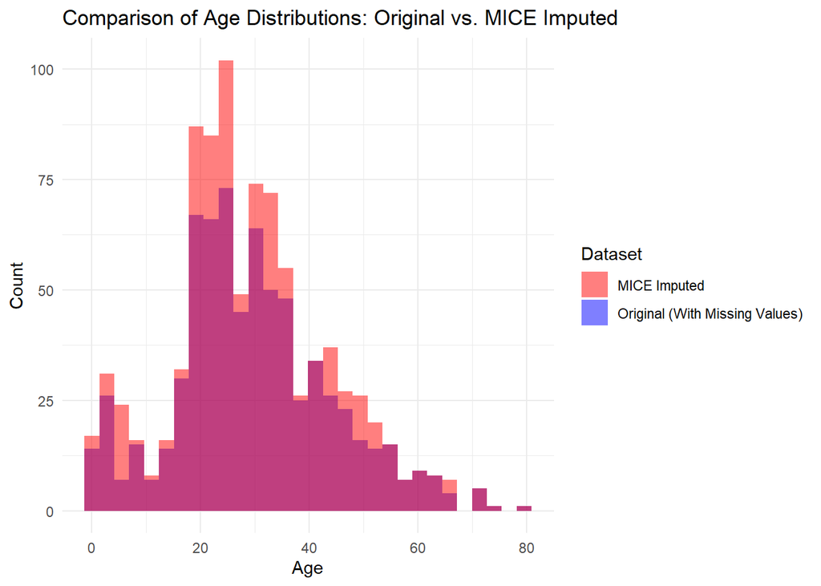

```r
# Compare distributions before and after MICE imputation
library(ggplot2)

ggplot() +
  geom_histogram(data = titanic_data, aes(x = Age, fill = "Original (With Missing Values)"), alpha = 0.5, bins = 30) +
  geom_histogram(data = titanic_data_mice, aes(x = Age, fill = "MICE Imputed"), alpha = 0.5, bins = 30) +
  theme_minimal() +
  labs(title = "Comparison of Age Distributions: Original vs. MICE Imputed", x = "Age", y = "Count") +
  scale_fill_manual(name = "Dataset", values = c("red", "blue"))
```

# 5 Conclusion

- **MICE provided a more flexible and statistically sound approach** for handling missing Age values compared to single imputation methods.
- **The imputed values reflect the natural distribution** of Age, reducing bias while maintaining variability.
- **This method is particularly useful when missing values are not missing completely at random (MCAR)** and need to be estimated based on other variables.

MICE is an **essential tool in machine learning** when working with incomplete datasets, ensuring that missing data does not compromise model accuracy. Its ability to **generate multiple plausible values** makes it preferable over simpler imputation techniques.